# Data 624 - Project 1

#### Output the Predictions

Below is a table containing the predictions for each ATM

```r
atm1.f <- ATM1.arima %>% forecast(h=31)
atm2.f <- ATM2.arima %>% forecast(h=31)
atm3.f <- ATM3.arima %>% forecast(h=31)
atm4.f <- ATM4.arima %>% forecast(h=31)

ATM.f <- cbind(atm1.f$mean,atm2.f$mean,atm3.f$mean,atm4.f$mean)

colnames(ATM.f) <- c("ATM1","ATM2","ATM3","ATM4")
row.names(ATM.f) <- as.Date(seq.Date(as.Date("2010/5/1"),by="day",length.out=31),format = "%Y-%m-%d")

kable(ATM.f)
```

|  | ATM1 | ATM2 | ATM3 | ATM4 |
| --- | --- | --- | --- | --- |
| 14730 | 86.70689 | 65.570389 | 76.518060 | 238.3850 |
| 14731 | 100.58583 | 71.420388 | 87.010739 | 346.0242 |
| 14732 | 73.68117 | 11.665773 | 43.414625 | 421.9467 |
| 14733 | 4.23253 | 2.506298 | 4.046689 | 158.9724 |
| 14734 | 100.16166 | 98.076872 | 99.373513 | 385.1930 |
| 14735 | 79.34712 | 89.044895 | 85.713901 | 264.4395 |
| 14736 | 85.75795 | 65.813527 | 76.793954 | 326.8497 |
| 14737 | 87.20172 | 65.595578 | 76.579836 | 207.1759 |
| 14738 | 100.39771 | 71.435234 | 87.179046 | 382.2706 |
| 14739 | 73.68117 | 11.649449 | 43.306440 | 372.5236 |
| 14740 | 4.23253 | 2.505951 | 4.013465 | 199.9500 |
| 14741 | 100.16166 | 98.106872 | 99.533873 | 354.1557 |
| 14742 | 79.34712 | 89.033761 | 85.714920 | 242.4417 |
| 14743 | 85.75795 | 65.794021 | 76.665286 | 367.6915 |
| 14744 | 87.20172 | 65.612794 | 76.638523 | 291.4327 |
| 14745 | 100.39771 | 71.445892 | 87.266385 | 353.1292 |
| 14746 | 73.68117 | 11.638179 | 43.230970 | 366.2645 |
| 14747 | 4.23253 | 2.505590 | 4.000651 | 269.7907 |
| 14748 | 100.16166 | 98.127762 | 99.633279 | 355.3942 |
| 14749 | 79.34712 | 89.026356 | 85.698752 | 305.8082 |
| 14750 | 85.75795 | 65.780310 | 76.593109 | 346.2168 |
| 14751 | 87.20172 | 65.624554 | 76.685456 | 303.0557 |
| 14752 | 100.39771 | 71.453533 | 87.308673 | 354.6069 |
| 14753 | 73.68117 | 11.630400 | 43.180981 | 355.3480 |
| 14754 | 4.23253 | 2.505255 | 3.997501 | 296.6022 |
| 14755 | 100.16166 | 98.142302 | 99.692670 | 349.4277 |
| 14756 | 79.34712 | 89.021441 | 85.679321 | 314.7151 |
| 14757 | 85.75795 | 65.770676 | 76.554380 | 350.2818 |
| 14758 | 87.20172 | 65.632582 | 76.719640 | 325.2836 |
| 14759 | 100.39771 | 71.459002 | 87.327043 | 349.0576 |
| 14760 | 73.68117 | 11.625033 | 43.149243 | 351.8726 |

```r
write.csv(ATM.f,"ATM_predictions.csv")
```

## Part B – Forecasting Power

Part B consists of a simple dataset of residential power usage for January 1998 until December 2013. Your assignment is to model these data and a monthly forecast for 2014. The data is given in a single file. The variable ‘KWH’ is power consumption in Kilowatt hours, the rest is straight forward. Add this to your existing files above.

### Inspect the data

```r
#quick inspection and check for missing data
kable(tail(power))
```

| CaseSequence | YYYY-MMM | KWH |
| --- | --- | --- |
| 919 | 2013-Jul | 8415321 |
| 920 | 2013-Aug | 9080226 |
| 921 | 2013-Sep | 7968220 |
| 922 | 2013-Oct | 5759367 |
| 923 | 2013-Nov | 5769083 |
| 924 | 2013-Dec | 9606304 |

```r
kable(power[!complete.cases(power),])
```

| CaseSequence | YYYY-MMM | KWH |
| --- | --- | --- |
| 861 | 2008-Sep | NA |

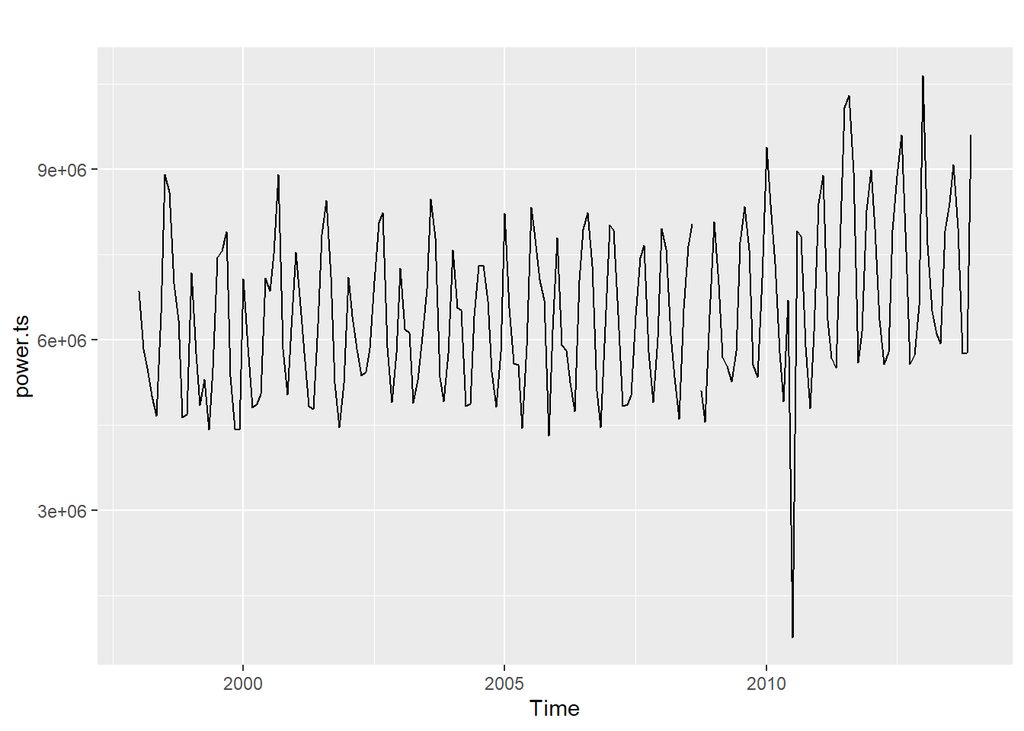

```r
power.ts <-ts(power$KWH, start = c(1998, 1), frequency = 12)

autoplot(power.ts )
```

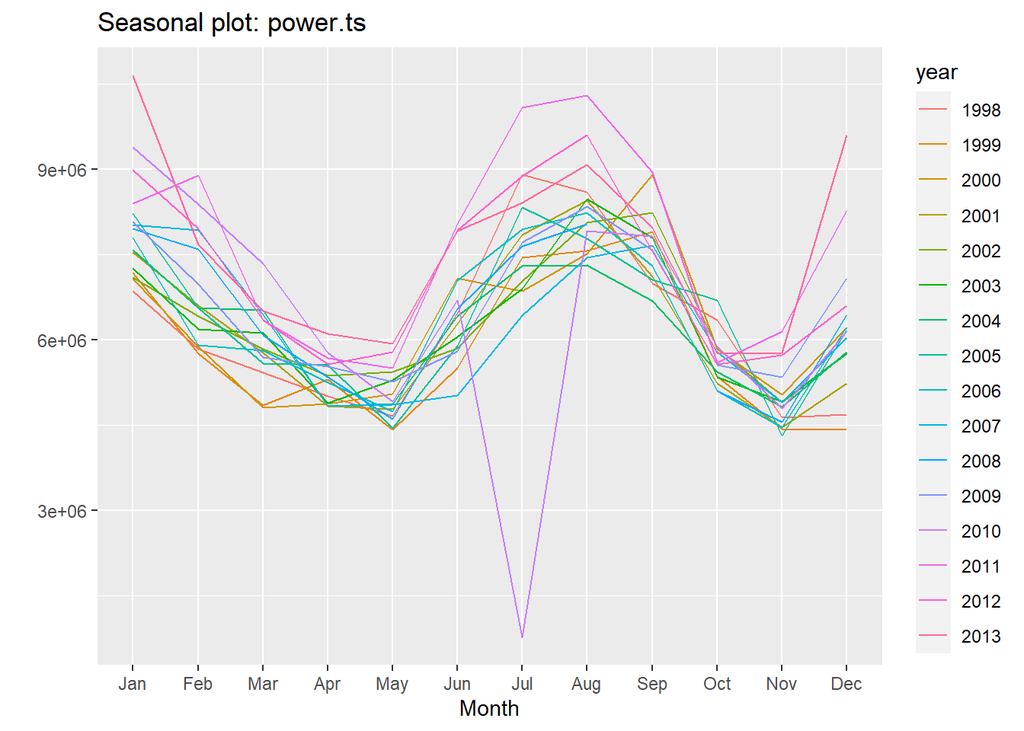

```r
ggseasonplot(power.ts )
```

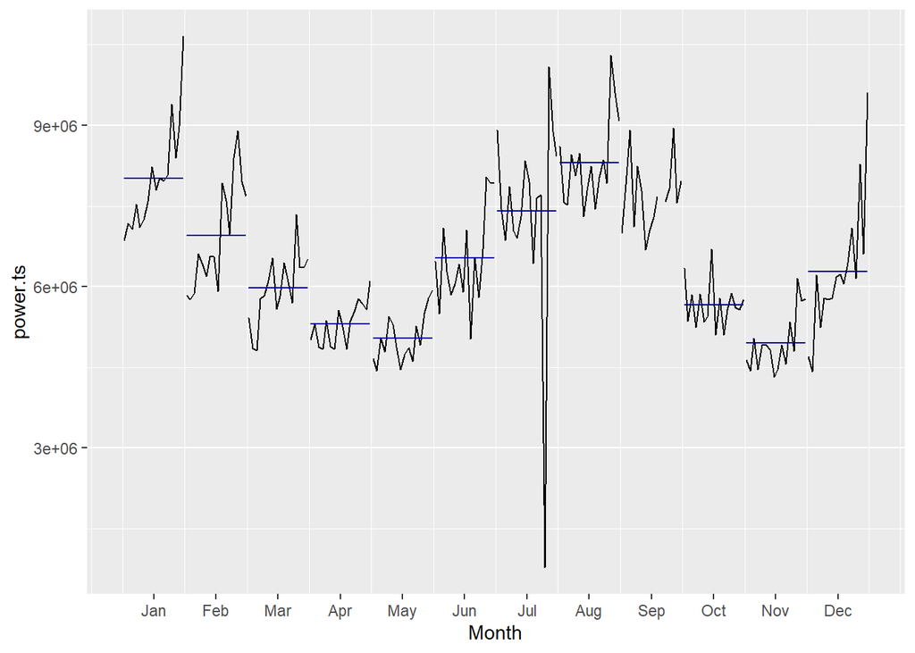

```r
ggsubseriesplot(power.ts )
```

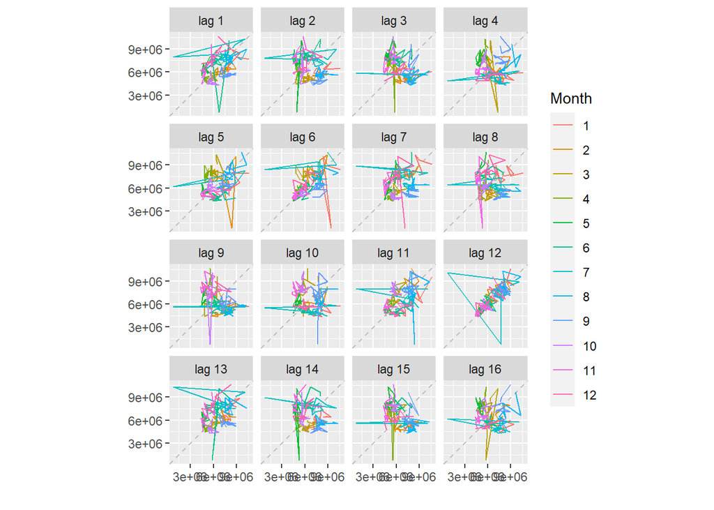

```r
gglagplot(power.ts )
```

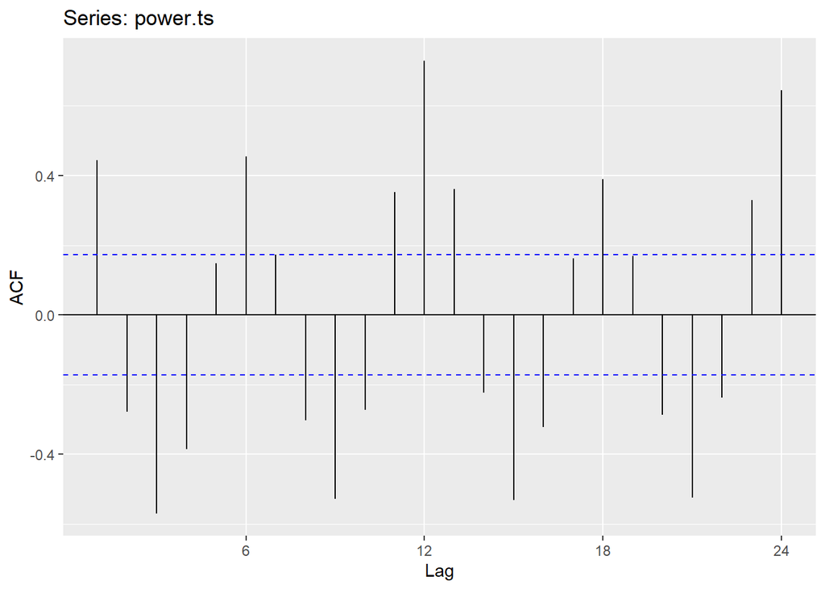

```r
ggAcf(power.ts )
```

We see only 1 missing case in the table above (sept 2008) which we can interpolate using the mean sept values based on what we see above. We also see an extreme value in july 2010.

We can see from the time series plot that the data has no major long-term trend and reasonably stable variability, tho there is an indication that the amplitude may be increasing post-2010. There is a pronounced seasonality visible in the timeseries plot and more specifically, the seasonal plot - summer and winter equate to higher power consumption than do fall and spring.

The seasonality is also abundantly clear in the ACF plot.

The seasonality and lag both suggest that we want to use a 12 month lag when evaluating this data. We will also try a BoxCox transformation given that the variability appears to be picking up towards the end of the series

```r
#find missing idx
idx <- which(!complete.cases(power))

#collect all values from same month
sept.kwh <- power$KWH[seq.int(9, length(power$KWH), 12L)]

#compute mean and inject
power$KWH[idx] <- mean(sept.kwh,na.rm = T)

#power$KWH <- Winsorize(power$KWH )

#rebuild the TS
power.ts <-ts(power$KWH, start = c(1998, 1), frequency = 12)
```